# College Admissions

Tseten Sherpa, Tiffany LaTorre, Surakshya Karki, Shreeja Dahal

December 2, 2021

Introduction

Students waiting to apply for college often find themselves wondering “Do I have what it takes to get admitted to the college of my choice?” One might think that their SAT score is the most important factor needed to bring them closer to a college education, while others may believe that college admissions are merely a game of chances and one’s ability to pay the tuition fees. According to bestvaalueschools.com, some colleges and universities also weigh a student’s character in the admissions equation. In this project, group 7 will report on factors that are taken into consideration by universities/colleges while offering a student an admission. The team members will analyze the “College Admissions” dataset extracted from Kaggle revolving around college admissions/class demographic according to various universities across the 50 states.

Data

The dataset represents various factors that generally play an important role in a college admission decision/process. It contains information about colleges/universities across the 50 states including but not limited to the cut-off SAT and ACT scores, the number of applications received, number of applicants accepted(including full-time and part-time), tuition fees, diversity representation, graduation rate, financial aid, and grant. In total, the dataset comprises 108 columns, 1517 rows, including categorical, discrete, and continuous variables. Some missing values are reported across the dataset in various variables. Any information on how the data was curated is not mentioned on the website from where the dataset was extracted.

Methodology

Results

Let’s look into the dataframe to find out which Universities/Colleges have highest and lowest number of applicants, admission rates, and test scores.

——————————————- 1.1 ———————————————————-

```
                                   Name Total Applicants
85 University of California-Los Angeles            72676
```

University of California-Los Angeles has the highest number of Applicants with a total number of of 72676 applicants.

—————————————– 1.2 —————————————————-

```
              Name Total Applicants
615 Kuyper College              152
```

Kuyper College has the lowest number of Applicants with a total number of 152 applicants.

———————————————– 2.1 ————————————————-

```
                                 Name Admission Rate
710 Montana State University-Northern            100
```

Montana State University-Northern has the highest number of acceptance rate: with 100% acceptance rate.

————————————— 2.2 ——————————————————-

```
##                   Name Admission Rate
## 545 Harvard University              6
```

Harvard University has the lowest number of acceptance rate: 6% acceptance rate

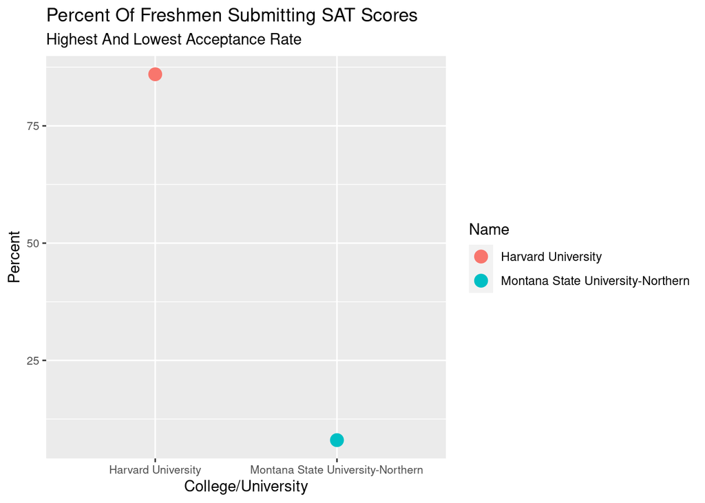

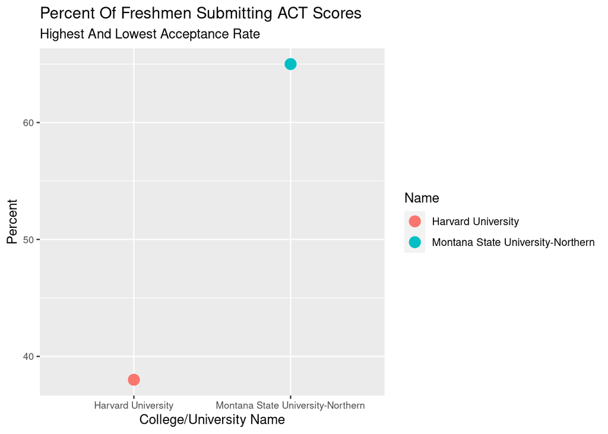

——————————————— 3.1 ————————————————

```
                                       Name Total Enrollment
1310 Texas A & M University-College Station            10241
```

Texas A & M University-College Station has the highest number of enrollment with 10241 students enrolled.

——————————————– 3.2 ————————————————–

```
                        Name Total Enrollment
32 Alaska Pacific University               33
```

Alaska Pacific University has the lowest number of enrollment with 33 students enrolled.

——————————————— 4.1 ————————————————

```
                Name Total SAT scores submission(in Percent)
1070 Cabrini College                                     100
```

The college with the highest percent of freshmen who submitted SAT scores is Cabrini College, with 100% submission rate.

—————————————— 4.2 ——————————————-

```
                                    Name
46 Arkansas State University-Main Campus
   Total SAT scores submission(in Percent)
46                                       1
```

The college with the lowest percent of freshmen who submitted SAT scores is Arkansas State University-Main Campus, with 1% submission rate.

——————————————– 5.1 ————————————————

```
                Name Total ACT scores submission(in Percent)
407 Baker University                                     100
```

The college with the highest percent of freshmen who submitted ACT scores is Baker University, with 100% submission rate. It can be understood that some applicants chose to submit both SAT and ACT scores.

————————————— 5.2 ———————————————-

```
                           Name Total ACT scores submission(in Percent)
840 The College of New Rochelle                                       1
```

The college with the lowest percent of freshmen who submitted ACT scores is The College of New Rochelle, with 1% submission rate.

—————————————- 6.1 —————————————————

```
                                 Name Full time undergraduate enrollment
999 Ohio State University-Main Campus                              40020
```

Ohio State University-Main Campus had the highest number of full time undergraduate enrollment with 40020 enrollments.

————————————— 6.2 ———————————————–

```
                     Name Full time undergraduate enrollment
1353 College of St Joseph                                120
```

—————————————— 6.3 —————————————————–

```
                             Name Part time undergraduate enrollment
197 University of Central Florida                              15104
```

University of Central Florida has the highest number of part time undergraduate enrollment with 15104 enrollments.

—————————————————- 6.4 —————————————————-

```
                                 Name Part time undergraduate enrollment
65 California Institute of Technology                                  0
```

California Institute of Technology has the lowest number of part time undergraduate enrollment with 0 enrollments.

—————- SAT & ACT SCORES ANALYSIS —————————–

——————-Schools that accepted the lowest SAT scores in 75th Percentile ————————–

```
                 Name Lowest SAT Score In 75th Percentile
1        Rust College                                1160
2 Livingstone College                                1210
3       Paine College                                1280
4   Chowan University                                1290
5     Fisk University                                1300
```

———————–Schools that accepted the highest SAT scores in 75th Percentile ——————-

```
                                Name Highest SAT Score In 75th Percentile
1                 Harvard University                                 2400
2 California Institute of Technology                                 2390
3                    Yale University                                 2390
4               Princeton University                                 2390
5              University of Chicago                                 2370
```

————————- Schools that accepted the lowest SAT scores in 25th Percentile ————————–

```
                                  Name Lowest SAT Score In 25th Percentile
1                  Livingstone College                                 950
2                         Rust College                                 970
3                        Paine College                                1010
4            Kentucky State University                                1016
5 University of Arkansas at Pine Bluff                                1018
```

————————— Schools that accepted the highest SAT scores in 25th Percentile ————————–

```
                                   Name Highest SAT Score In 25th Percentile
1    California Institute of Technology                                 2210
2                 University of Chicago                                 2140
3                       Yale University                                 2120
4                    Harvard University                                 2120
5 Massachusetts Institute of Technology                                 2120
```

———————- Schools that offers the lowest financial aid —————————

```
              Name Percent of Freshmen Receiving Any Financial Aid
67 Trinity College                                              41
```

—————————- Schools that offers the highest financial aid —————————

```
            Name Percent of Freshmen Receiving Any Financial Aid
3 Judson College                                             100
```

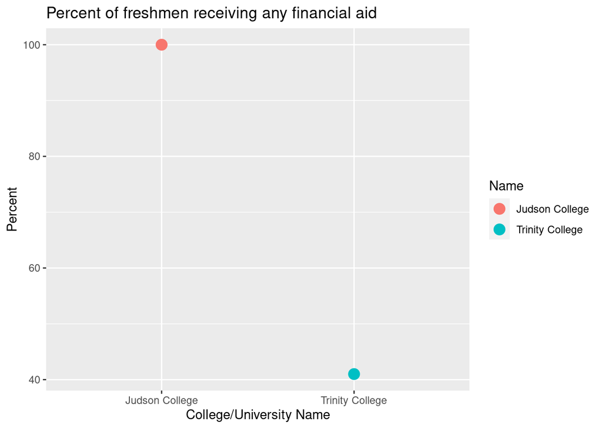

Trinity College gives out the least financial aid i.e, only about 41% of the students at Trinity College receive any financial aid. Judson College on the other hand, gives out about 100% financial aid to students.

The top five schools with the lowest number of women enrollment are shown in the graph below.

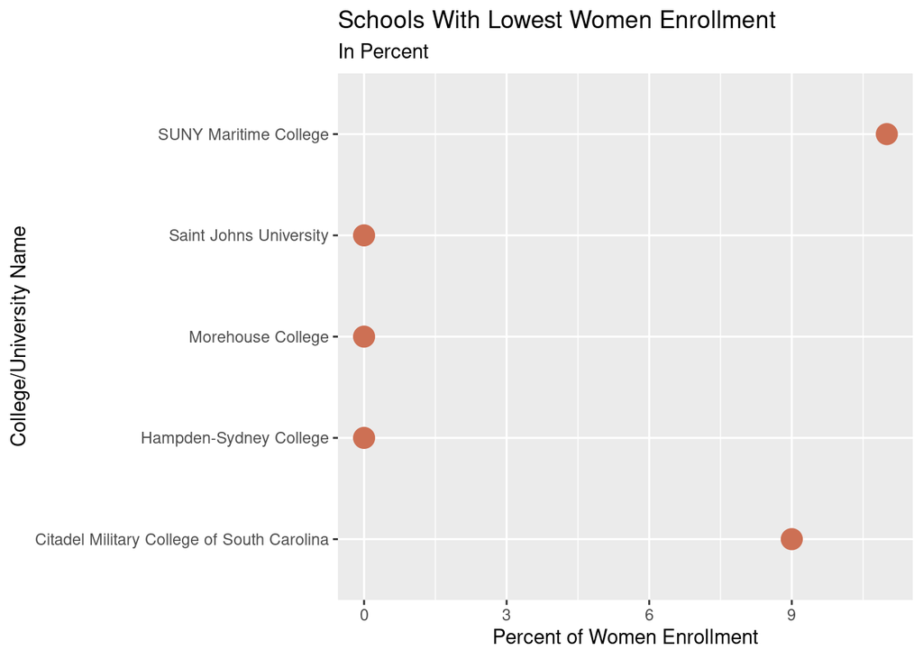

The top 5 schools with the least women enrollment are: 1. Morehouse College with 0% women enrollment  
2. Saint Johns University 0% women enrollment  
3. Hampden-Sydney College 0% women enrollment  
4. Citadel Military College of South Carolina 9% women enrollment  
5. SUNY Maritime College 11% women enrollment

Predictions

```
# A tibble: 3 × 5
  term                                      estimate std.error statistic  p.value
  <chr>                                        <dbl>     <dbl>     <dbl>    <dbl>
1 (Intercept)                                 76.9      5.76       13.4  2.93e-36
2 Percent.of.freshmen.submitting.SAT.scores   -0.125    0.0522     -2.39 1.69e- 2
3 Percent.of.freshmen.submitting.ACT.scores   -0.142    0.0561     -2.53 1.15e- 2
```

Discussion